# Case Study III

## 3.6 Cronbach’s Alpha

Cronbach’s $\alpha$ provides an overall assessment of a measure’s reliability for a set of survey items. If the $\alpha$ is relatively high, this means that there is internal consistency between the questions. Unfortunately, this does not show any dimensionality and that is why the EDA was in part utilized above.

*Note*: Only the images were used for Cronbach $\alpha$ to ensure that all questions had no missing values. Otherwise, most of the values would be below the threshold of 0.70.

```r
# Create a data frame with two columns
my_table1 <- data.frame(
  Model = c("Aesthetic", "Retal_Envrnmnt", "Assortment", "Cultural_Refinement", "Gourmet", "High_end_Brands", "Fashionable", "Corporate_Imag"),
  Alpha = c(91.3, 88.6, 92.9, 88.2, 93.3, 85.9, 90.2, 80.6))

# Print the table
print(my_table1)
```

```
##                 Model Alpha
## 1           Aesthetic  91.3
## 2      Retal_Envrnmnt  88.6
## 3          Assortment  92.9
## 4 Cultural_Refinement  88.2
## 5             Gourmet  93.3
## 6     High_end_Brands  85.9
## 7         Fashionable  90.2
## 8      Corporate_Imag  80.6
```

A general rule for the Alpha’s threshold would be 0.7, and all constructs exceed that value.

```r
modificationindices(fit1) |> filter(mi > 10)
```

```
##          lhs op  rhs     mi    epc sepc.lv sepc.all sepc.nox
## 1 Assortment =~ Im20 14.627 -0.149  -0.195   -0.131   -0.131
## 2    Gourmet =~ Im13 11.344 -0.222  -0.180   -0.150   -0.150
## 3    Gourmet =~ Im12 11.344  0.186   0.151    0.133    0.133
## 4       Im20 ~~ Im21 11.943  0.233   0.233    0.342    0.342
## 5       Im22 ~~ Im21 15.754 -0.292  -0.292   -0.466   -0.466
```

# 4 Question 1

**What are the dimensions by which Galeries Lafayette is perceived? Please explain your findings and rational for your final result.**

There were two factor analyses completed, exploratory and confirmatory. The EFA is a statistical technique that is used to minimize data to a smaller set of summary variables and to explore the underlying theoretical structure of the phenomena [3]. However, CFA is a multivariate statistical procedure that is utilized to test how well the measured variables represent the number of constructs [4]. The first step to analyzing the 22 image questions was to conduct an EFA. All of the details can be found under Part II as to how and why this specific model was chosen. The final model has 8-factors, and excluded questions 8, 9, 11, and 15 which were about Expertise in French Traditional Cuisine, French Fashion, High-quality Cosmetics, and Professional Selection of Brands. Therefore, the eight dimensions that were considered are the following:

1. Aesthetic
2. Retail_Environment
3. Gourmet
4. Assortment
5. French
6. High_end_Brands
7. Fashionable
8. Corporate_Image

In the next analysis under CFA, the results results in the same dimensions. For more details about this final model, please refer to Part III. The finalized factors are:

1. Aesthetic
2. Retail_Environment
3. Gourmet
4. Assortment
5. French
6. High_end_Brands
7. Fashionable
8. Corporate_Image

Overall, Galaries Lafayette should rely on the CFA’s model’s eight dimensions above when trying to understand how customers view and perceive this business.

**Resources** [3] https://www.statisticssolutions.com/free-resources/directory-of-statistical-analyses/exploratory-factor-analysis/ [4] https://www.statisticssolutions.com/free-resources/directory-of-statistical-analyses/confirmatory-factor-analysis/

# 5 Part IV: Structural Equation Model (SEM)

The mediators are given as Customer Satisfaction (SAT1_4) and Affective Commitment (COM1_4). Since there are various columns for each, a CFA model was run to combine the variables into one mediator. In this step, we did the same thing for the outcomes, Repurchase Intention (C_REP1_4) and Cocreation Intention (C_CRI1_4). Furthermore, we will build our SEM model below to idenitfy indirect, direct and total effects.

## 5.1 Constructing SEM

```r
# Define the measurement model for the 8 factors without q/ 8,9,11,15
Latent_Factors <-
' # Latent Factors
Aesthetic =~ Im4 + Im3 + Im5
Retail_Environment =~ Im20 + Im22 + Im21
Assortment =~ Im1 + Im2
French =~ Im7 + Im6
Gourmet =~ Im10 + Im14
High_end_Brands =~ Im13 + Im12
Fashionable =~ Im17 + Im18
Corporate_Image =~ Im16 + Im19

# Define the latent variables
# Latent Variables
COM1_4 =~ COM_A1 + COM_A2 + COM_A3 + COM_A4
SAT1_3 =~ SAT_1 + SAT_2 + SAT_3
C_REP1_4 =~ C_REP1 + C_REP2 + C_REP3
C_CR1_4 =~ C_CR1 + C_CR2 + C_CR3'

#Define structural model with the mediators and latent factors
Regression_Paths <-
'#regression paths factors on SAT
SAT1_3 ~ a*Aesthetic + b*Retail_Environment + c*Assortment + d*French + e*Gourmet + f*High_end_Brands + g*Fashionable + h*Corporate_Image

#regression paths factor on COM
COM1_4 ~ i*Aesthetic + j*Retail_Environment + k*Assortment + l*French + m*Gourmet + n*High_end_Brands + o*Fashionable + p*Corporate_Image

# Define structural model with the mediators and outcomes
#direct effect of the mediatiors on REP
C_REP1_4 ~ q*SAT1_3 + s*COM1_4
#direct effect of the mediators on CRQ
C_CR1_4 ~ r*SAT1_3 + t*COM1_4

#regression: total effect of factors on Repurchase Intention
C_REP1_4 ~ ac*Aesthetic + ad*Retail_Environment + ae*Assortment + af*French + ag*Gourmet + ah*High_end_Brands + ai*Fashionable + aj*Corporate_Image

#regression: total effect on Cocreation Intention
C_CR1_4 ~ u*Aesthetic + v*Retail_Environment + w*Assortment + x*French + y*Gourmet + z*High_end_Brands + aa*Fashionable + ab*Corporate_Image'

# Define structural model for total effect
Model_Structural <-
'# Indirect Effect factors to Repurchase Intention
aq := a*q
bq := b*q
cq := c*q
dq := d*q
eq := e*q
fq := f*q
gq := g*q
hq := h*q

# Indirect Effect factors to Cocreation Intention
ar := a*r
br := b*r
cr := c*r
dr := d*r
er := e*r
fr := f*r
gr := g*r
hr := h*r

# Indirect Effect factors to Repurchase Intention
is := i*s
js := j*s
ks := k*s
ls := l*s
ms := m*s
ns := n*s
os := o*s
ps := p*s

# Indirect Effect factors to Cocreation Intention
it := i*t
jt := j*t
kt := k*t
lt := l*t
mt := m*t
nt := n*t
ot := o*t
pt := p*t

#Total Indirect effect of factors to Repurchase Intention
we := aq + is
te := bq + js
ye := cq + ks
ue := dq + ls
ie := eq + ms
oe := fq + ns
pe := gq + os
ae := hq + ps

#Total Indirect effect of factors to Cocreation Intention
se := ar + it
de := br + jt
fe := cr + kt
ge := dr + lt
he := er + mt
je := fr + nt
ke := gr + ot
le := hr + pt

# Total effect of factor on outcome Repurchase Intention
te_fac1 := we + ac
te_fac2 := te + ad
te_fac3 := ye + ae
te_fac4 := ue + af
te_fac5 := ie + ag
te_fac6 := oe + ah
te_fac7 := pe + ai
te_fac8 := ae + aj

# Total effect of factor on outcome Cocreation Intention
te_fac12 := se + u
te_fac22 := de + v
te_fac32 := fe + w
te_fac42 := ge + x
te_fac52 := he + y
te_fac62 := je + z
te_fac72 := ke + aa
te_fac82 := le + ab
'

# Combine the model specification into a single string
model <- paste(Latent_Factors, Regression_Paths, Model_Structural, sep = "\n")

# Fit the model to the data
fit5 <- cfa(model = model, data = lafayette, missing = "ML")

# Inspect the output
summary(fit5, fit.measures = TRUE, standardized = TRUE)
```

```
## lavaan 0.6.15 ended normally after 142 iterations
##
##   Estimator                                         ML
##   Optimization method                           NLMINB
##   Number of model parameters                       158
##
##   Number of observations                           553
##   Number of missing patterns                       139
##
## Model Test User Model:
##
##   Test statistic                               642.461
##   Degrees of freedom                               369
##   P-value (Chi-square)                           0.000
##
## Model Test Baseline Model:
##
##   Test statistic                             11429.390
##   Degrees of freedom                               465
##   P-value                                        0.000
##
## User Model versus Baseline Model:
##
##   Comparative Fit Index (CFI)                    0.975
##   Tucker-Lewis Index (TLI)                       0.969
##
##   Robust Comparative Fit Index (CFI)             0.975
##   Robust Tucker-Lewis Index (TLI)                0.969
##
## Loglikelihood and Information Criteria:
##
##   Loglikelihood user model (H0)             -21704.041
##   Loglikelihood unrestricted model (H1)     -21382.811
##
##   Akaike (AIC)                               43724.083
##   Bayesian (BIC)                             44405.909
##   Sample-size adjusted Bayesian (SABIC)      43904.347
##
## Root Mean Square Error of Approximation:
##
```

[output cut: 296 more lines]

```
##     te_fac2           0.121    0.028    4.278    0.000    0.255    0.255
##     te_fac3           0.175    0.038    4.584    0.000    0.301    0.301
##     te_fac4           0.025    0.031    0.828    0.408    0.048    0.048
##     te_fac5           0.062    0.046    1.332    0.183    0.084    0.084
##     te_fac6           0.023    0.034    0.672    0.502    0.042    0.042
##     te_fac7          -0.013    0.032   -0.412    0.680   -0.027   -0.027
##     te_fac8           0.092    0.058    1.579    0.114    0.142    0.142
##     te_fac12         -0.016    0.085   -0.191    0.849   -0.013   -0.013
##     te_fac22          0.301    0.083    3.643    0.000    0.240    0.240
##     te_fac32          0.009    0.081    0.109    0.913    0.007    0.007
##     te_fac42         -0.039    0.089   -0.433    0.665   -0.028   -0.028
##     te_fac52         -0.035    0.136   -0.259    0.796   -0.018   -0.018
##     te_fac62         -0.025    0.100   -0.251    0.802   -0.018   -0.018
##     te_fac72          0.024    0.094    0.251    0.802    0.018    0.018
##     te_fac82         -0.212    0.168   -1.263    0.207   -0.123   -0.123
```

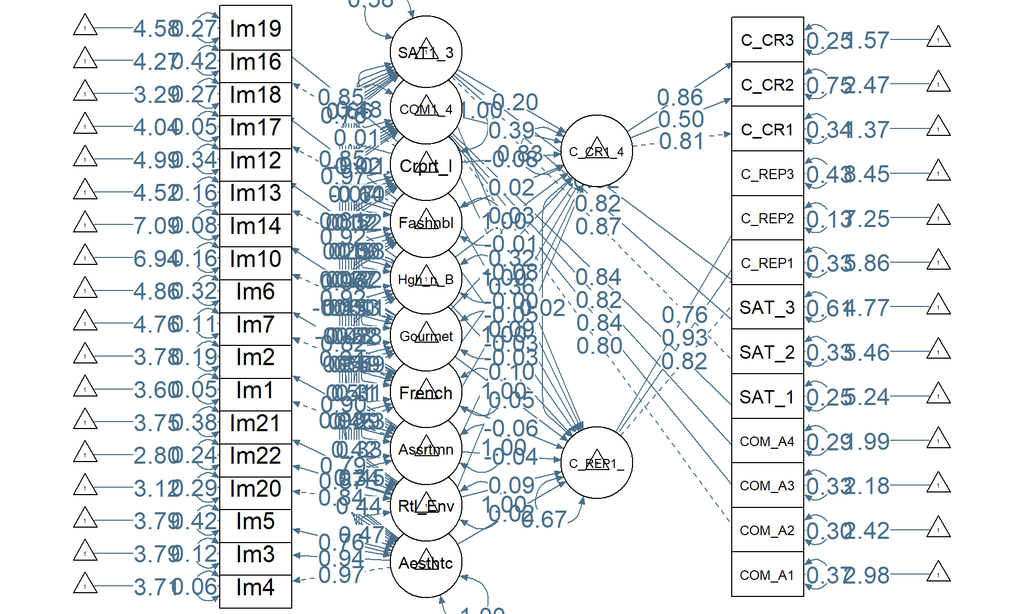

```r
# Path analysis
semPaths(fit5, what = "path", whatLabels = "std", style = "mx",
         rotation = 2, layout = "tree3", mar = c(1, 2, 1, 2),
         nCharNodes = 7,shapeMan = "rectangle", sizeMan = 8, sizeMan2 = 5,
         curvePivot=TRUE, edge.label.cex = 1.2, edge.color = "skyblue4")
```